# R Lab 2 Key

## Libraries

You will need to load the following libraries this week

```r
library(ggplot2)
library(viridis)
library(psych)
```

## The Data

This week you will be using data with information test performance. Let’s load it in and take a peek at it.

```r
mydata <- read.csv("Data/SampleDataSet.csv")
head(mydata)
```

```
##   ID Gender    Treatment Test1 Test2
## 1  1   Male      Control    98    32
## 2  2 Female Experimental    87    33
## 3  3 Female      Control    89    54
## 4  4 Female      Control    88    44
## 5  5   Male Experimental    76    64
## 6  6   Male      Control    68    54
```

The `psych` library has a `describe()` function that gives a lot of helpful information.

```r
describe(mydata)
```

```
##            vars  n  mean    sd median trimmed   mad min max range  skew
## ID            1 25 13.00  7.36     13   13.00  8.90   1  25    24  0.00
## Gender*       2 25  1.44  0.51      1    1.43  0.00   1   2     1  0.23
## Treatment*    3 25  1.32  0.48      1    1.29  0.00   1   2     1  0.73
## Test1         4 25 83.52  8.63     86   83.76 10.38  65  98    33 -0.24
## Test2         5 25 64.24 21.64     64   64.00 29.65  32  99    67  0.04
##            kurtosis   se
## ID            -1.34 1.47
## Gender*       -2.02 0.10
## Treatment*    -1.53 0.10
## Test1         -0.79 1.73
## Test2         -1.38 4.33
```

## The Mean

### Exercise 1: Find the mean of Test1

```r
mean(mydata$Test1, na.rm = TRUE)
```

```
## [1] 83.52
```

### Exercise 2: Find the mean of Test2

```r
mean(mydata$Test2, na.rm = TRUE)
```

```
## [1] 64.24
```

### Exercise 3: Which test did people perform better on?

RESPONSE: First Test

## Variance

### Exercise 4: Find the variance of Test1

```r
var(mydata$Test1)
```

```
## [1] 74.42667
```

### Exercise 5: Interpret how this variance relates to the Test1 data.

Response: Because the variance is high (74), we can see that there is high variability and individuals in the group are spread out very far.

### Exercise 6: Find the standard deviation of Test1

```r
sd(mydata$Test1)
```

```
## [1] 8.627089
```

### Exercise 7: Interpret how this standard deviation relates to the Test1 data and its mean.

Response: The mean Test1 performance is 83.52. The standard deviation is is 8.63. A small standard deviation means that the values in a dataset are close to the mean (or average) of the dataset, and a large standard deviation means that the values in the dataset are farther away from the mean. The standard deviation is in original units. This means, it is in the unit of test points. One standard deviation is roughly 9 points, which is almost a whole letter grade! This is pretty big variability. In situations where you just observe and record data, a large standard deviation isn’t necessarily a bad thing; it just reflects a large amount of variation in the group that is being studied.

### Exercise 8: Find the variance of Test2

```r
var(mydata$Test2)
```

```
## [1] 468.3567
```

### Exercise 9: Interpret how this variance relates to the Test2 data.

Response: Because the variance is EXTREMELY high, we can see that there is high variability and individuals in the group are spread out very far.

### Exercise 10: Find the standard deviation of Test2

```r
sd(mydata$Test2)
```

```
## [1] 21.64155
```

### Exercise 11: Interpret how this standard deviation relates to the Test1 data and its mean.

Response: The mean Test2 performance is 64.24. The standard deviation is is 21.64155. One standard deviation is roughly 22 points, which 2 letter grades! This is pretty big variability.

### Exercise 12: Fill in the blanks below. The goal is to create three object for Test1.

In the first blank, compute the mean of Test1. The second and third blank should be identical and you should compute the standard deviation of Test1.

```r
mean_test1 <- mean(mydata$Test1)
sd_above1 <- mean_test1 + sd(mydata$Test1)
sd_below1 <- mean_test1 - sd(mydata$Test1)
```

If you were able to correctly assign the values above, the code below will run without error.

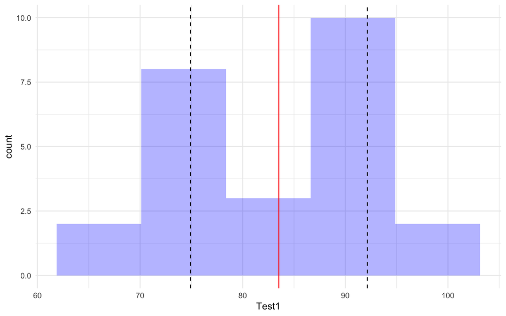

```r
ggplot(mydata, aes(Test1)) +
  geom_histogram(bins = 5, alpha = 0.3,
                 fill = "blue") +
  theme_minimal() +
  geom_vline(xintercept = mean_test1, color = "red") +
  geom_vline(xintercept = c(sd_below1, sd_above1),
             color = "black", linetype = "dashed")
```

### Exercise 13: Fill in the blanks below. The goal is to create three object for Test2.

In the first blank, compute the mean of Test2. The second and third blank should be identical and you should compute the standard deviation of Test2.

```r
mean_test2 <- mean(mydata$Test2)
sd_above2 <- mean(mydata$Test2) + sd(mydata$Test2)
sd_below2 <- mean(mydata$Test2) - sd(mydata$Test2)
```

If you were able to correctly assign the values above, the code below will run without error.

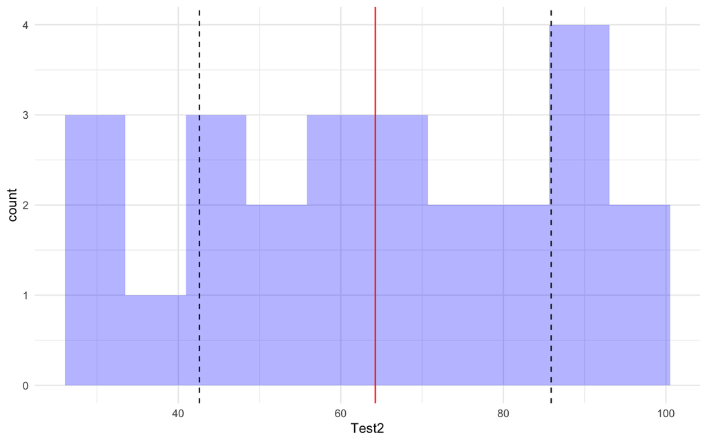

```r
ggplot(mydata, aes(Test2)) +
  geom_histogram(bins = 10, alpha = 0.3,
                 fill = "blue") +
  theme_minimal() +
  geom_vline(xintercept = mean_test2, color = "red") +
  geom_vline(xintercept = c(sd_below2, sd_above2),
             color = "black", linetype= "dashed")
```

### Exercise 14: Look at both histograms and interpret what you see.

Answer: As we calculated previously, Test2 has much higher variability around the mean compared to Test1.